# hw4final

Emily Brown

2024-11-08

```r
knitr::opts_chunk$set(echo = TRUE)

# List of packages necessary to run this script:
require(librarian, quietly = TRUE)
shelf(tidyverse,
      maps, # For US state map
      lme4,
      DHARMa,
      mgcViz,
      mgcv, # For checking model convergence
      MuMIn, # for model selection
      gratia, # for ggplot functionality with mgcv
      mice,
      sf,
      lib = tempdir(),
      quiet = TRUE)

# Set the web address where R will look for files from this repository
# Do not change this address
repo_url <- "https://raw.githubusercontent.com/LivingLandscapes/Course_EcologicalModeling/master/"

# Load data
weather <-
  read_csv(paste0(repo_url, "data/FireWeather.csv"))

# Brief looks at the data:
head(weather)
```

```
## # A tibble: 6 × 9
##    Year Veg_Type      Station_ID   Lat  Long Month   Day Wind_mph_max RH_per_min
##   <dbl> <chr>         <chr>      <dbl> <dbl> <dbl> <dbl>        <dbl>      <dbl>
## 1  2010 Edwards Plat… KGRK        31.1 -97.8     5   121         17.3       40.9
## 2  2010 Edwards Plat… KGRK        31.1 -97.8     5   122         16.1       26.3
## 3  2010 Edwards Plat… KGRK        31.1 -97.8     5   123         11.5       24.8
## 4  2010 Edwards Plat… KGRK        31.1 -97.8     5   124         11.5       20.9
## 5  2010 Edwards Plat… KGRK        31.1 -97.8     5   125         13.8       31.8
## 6  2010 Edwards Plat… KGRK        31.1 -97.8     5   126         19.6       38.0
```

```r
set.seed(54)
```

## Methods (analytical methods)

The aim of this project is to see if and how the relative humidity (hence refered to as RH) and wind speed is changing over time and space.

The weather data was collected from 2010 to 2019 across multiple weather stations situated along a latitudinal gradient in the United States Great Plains. The dataset includes daily measurements of two weather variables: minimum relative humidity (RH) and maximum wind speed (Wind_mph_max). Data were recorded for the period spanning days 121–273 of each year (approximately May through September), and each observation includes the year, station ID, geographic coordinates (latitude and longitude), and the day and month of the year.

In order to properly observe the how the response variables of interest (RH_per_min and Wind_mph_max) were changing over time, I first observed the data present. I also preemptively scaled the data as a separate file to account for any scaling issues that may arise.

**Data exploration**

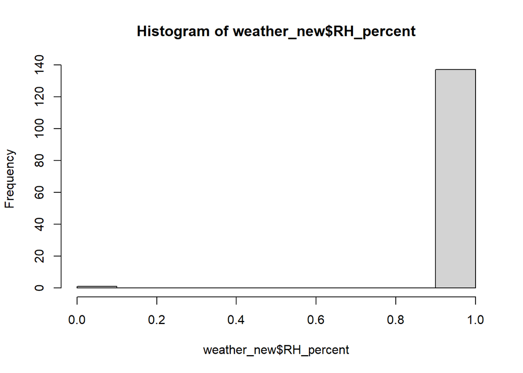

```r
##see scalehelp picture. Include NAs bc there are a lot.
scaleHelp <- function(x) ( x - mean(x)) / sd(x)
weather_new <-
  weather %>%
  mutate(RH_percent = RH_per_min / 100) %>%
  mutate(RH_percent = case_when(RH_percent < 0.00001 ~ 0.00001,
                                RH_percent > 0.99999 ~ 0.99999),
         RH_per_min = ifelse(RH_per_min < 0.00001, 0.00001, RH_per_min),
         Long_scaled = scaleHelp(Long),
         Lat_scaled = scaleHelp(Lat),
         Day_scaled = scaleHelp(Day),
         Month_scaled = scaleHelp(Month),
         Year_scaled = scaleHelp(Year))

#Response variable
hist(weather_new$RH_percent)
```

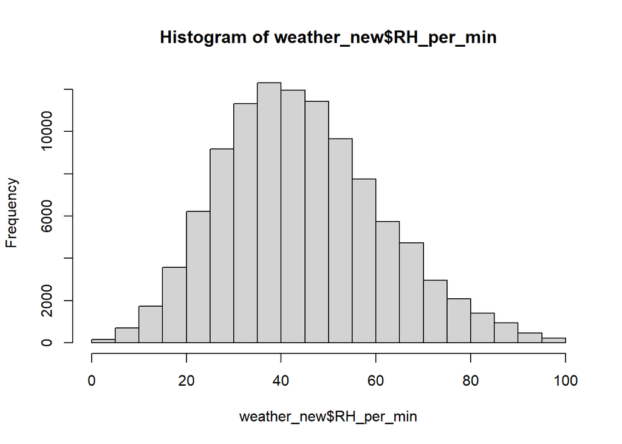

```r
hist(weather_new$RH_per_min)
```

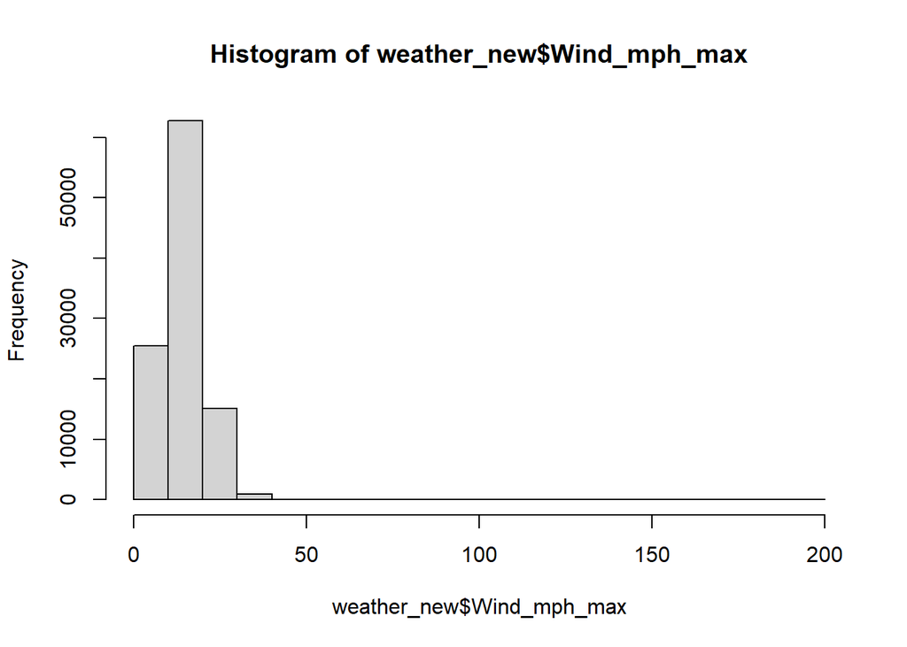

```r
hist(weather_new$Wind_mph_max)
```

I then checked the correlations of the scaled dataset. After doing so, it was observed that there was a high correlation between Month and Day. There was also very little correlation between Day and Year. This follows expectations, because Year is independent, and Day is a time unit inside of year. Additionally, since the Days are listed in a numerical format from 121-273, the Month variable was no longer considered to avoid redundancy.

Finally, I graphed the trends of both RH per min and max wind speed as days increase for each vegetation type. Overall, there looked to be a slightly higher humidity as the day increased. There also appeared to be a spike within the first 180 days, which is within expectations, as it does tend to rain a lot in the spring. Finally, it looked like in general, as days increased, the wind speed tended to decrease.

```r
#Pairwise correlations
cor(weather_new[ , 13:15])
```

```
##                Day_scaled Month_scaled  Year_scaled
## Day_scaled    1.000000000  0.979799613 -0.001569676
## Month_scaled  0.979799613  1.000000000 -0.001455277
## Year_scaled  -0.001569676 -0.001455277  1.000000000
```

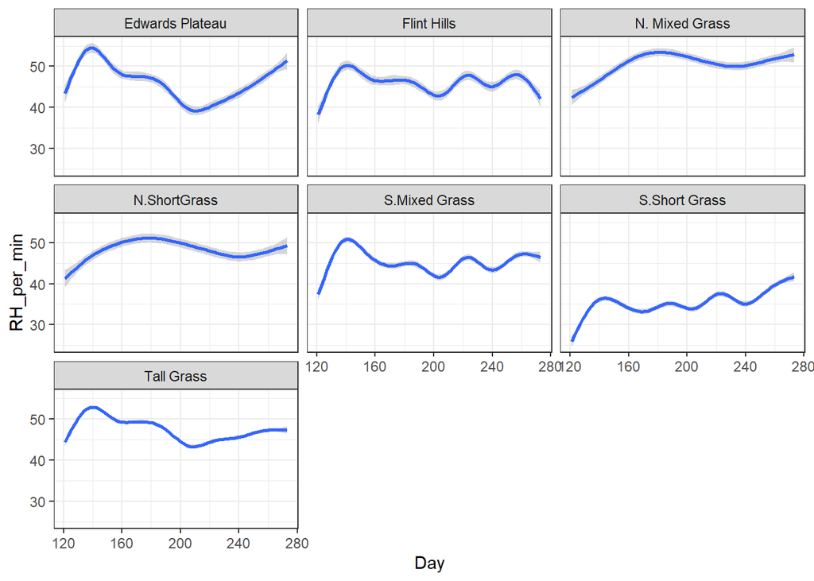

```r
#
ggplot(weather_new) +
  geom_smooth(aes(x = Day, y = RH_per_min)) +
  facet_wrap(~ Veg_Type) +
  theme_bw()
```

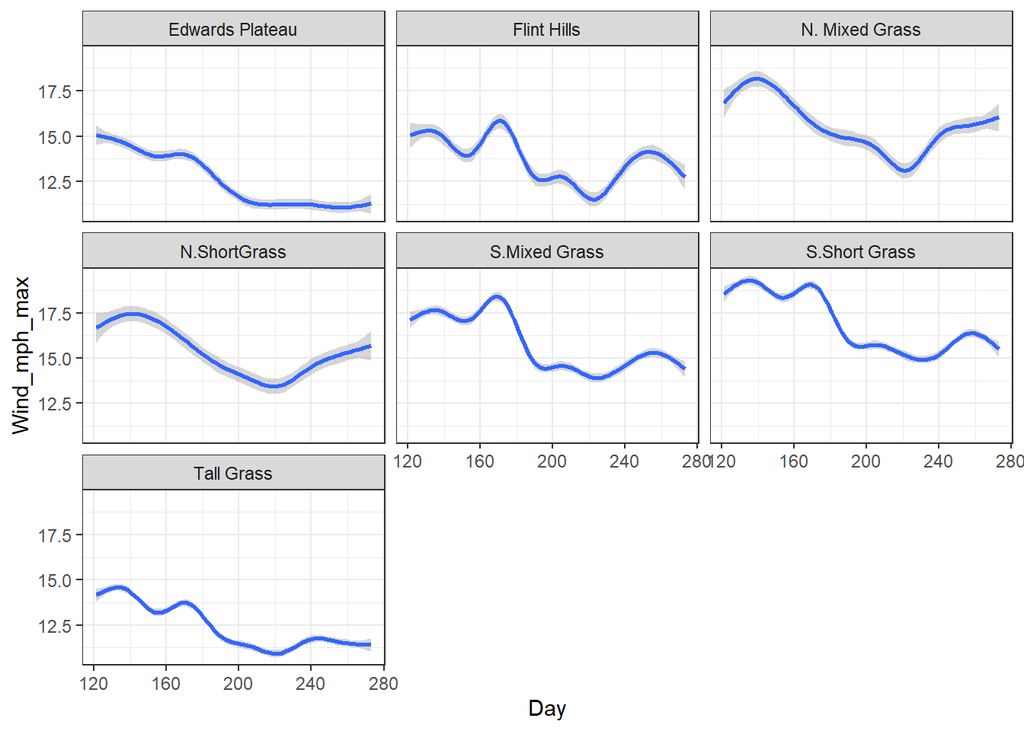

```r
ggplot(weather_new) +
  geom_smooth(aes(x = Day, y = Wind_mph_max),
              method = "gam") +
  facet_wrap(~ Veg_Type) +
  theme_bw()
```

```r
weather_new$Veg_Type <- as.factor(weather_new$Veg_Type)
weather_new$Station_ID <- as.factor(weather_new$Station_ID)
RH_gam1 <-
  bam(RH_per_min ~ te(Lat_scaled, Long_scaled)
      + te(Year_scaled, Day_scaled, by = Veg_Type) +
      s(Station_ID, bs = "re") + Veg_Type,
      family = gaussian("log"),
      data = weather_new)






weather_new$Wind_mph_max[weather_new$Wind_mph_max == 0] <- 0.01
weather_new$Wind_mph_max_logged <- log(weather_new$Wind_mph_max)

WS_gam1 <-
  bam(Wind_mph_max ~ te(Lat_scaled, Long_scaled)
      + te(Year_scaled, Day_scaled, by = Veg_Type) +
      s(Station_ID, bs = "re") + Veg_Type,
      family = gaussian("log"), na.action = na.omit,
      data = weather_new)
```

Now that the initial models are made, I then interrogated the models. I started with the RH model. The summary showed that most of the vegetation types did not have a significant effect on RH. The interaction of day and year by vegetation type is highly significant for all vegetation types. Additionally, this model shows some errors. For example the R squared value is low, meaning the model does a poor job explaining the variance. There are some variance issues in the plots as well. Finally, the VIF numbers are very large, which suggest multicollinearity issues.

```r
# Model summary
summary(RH_gam1)
```

```
##
## Family: gaussian
## Link function: log
##
## Formula:
## RH_per_min ~ te(Lat_scaled, Long_scaled) + te(Year_scaled, Day_scaled,
##     by = Veg_Type) + s(Station_ID, bs = "re") + Veg_Type
##
## Parametric coefficients:
##                        Estimate Std. Error t value Pr(>|t|)
## (Intercept)             3.78138    0.07237  52.249   <2e-16 ***
## Veg_TypeFlint Hills     0.05521    0.09479   0.582   0.5603
## Veg_TypeN. Mixed Grass  0.20743    0.16304   1.272   0.2033
## Veg_TypeN.ShortGrass    0.22536    0.17433   1.293   0.1961
## Veg_TypeS.Mixed Grass   0.02383    0.08258   0.289   0.7730
## Veg_TypeS.Short Grass  -0.19008    0.10628  -1.789   0.0737 .
## Veg_TypeTall Grass      0.02192    0.07381   0.297   0.7665
## ---
## Signif. codes:  0 '***' 0.001 '**' 0.01 '*' 0.05 '.' 0.1 ' ' 1
##
## Approximate significance of smooth terms:
##                                                       edf Ref.df       F
## te(Lat_scaled,Long_scaled)                          8.576  8.702   2.298
## te(Year_scaled,Day_scaled):Veg_TypeEdwards Plateau 23.034 23.904  51.207
## te(Year_scaled,Day_scaled):Veg_TypeFlint Hills     22.964 23.886  36.931
## te(Year_scaled,Day_scaled):Veg_TypeN. Mixed Grass  21.657 23.455  29.926
## te(Year_scaled,Day_scaled):Veg_TypeN.ShortGrass    21.749 23.496  26.745
## te(Year_scaled,Day_scaled):Veg_TypeS.Mixed Grass   23.306 23.945 125.790
## te(Year_scaled,Day_scaled):Veg_TypeS.Short Grass   23.251 23.928 170.634
## te(Year_scaled,Day_scaled):Veg_TypeTall Grass      23.690 23.989 185.471
## s(Station_ID)                                      56.558 63.000  56.135
##                                                    p-value
## te(Lat_scaled,Long_scaled)                          0.0109 *
## te(Year_scaled,Day_scaled):Veg_TypeEdwards Plateau  <2e-16 ***
## te(Year_scaled,Day_scaled):Veg_TypeFlint Hills      <2e-16 ***
## te(Year_scaled,Day_scaled):Veg_TypeN. Mixed Grass   <2e-16 ***
## te(Year_scaled,Day_scaled):Veg_TypeN.ShortGrass     <2e-16 ***
## te(Year_scaled,Day_scaled):Veg_TypeS.Mixed Grass    <2e-16 ***
## te(Year_scaled,Day_scaled):Veg_TypeS.Short Grass    <2e-16 ***
## te(Year_scaled,Day_scaled):Veg_TypeTall Grass       <2e-16 ***
## s(Station_ID)                                       <2e-16 ***
## ---
## Signif. codes:  0 '***' 0.001 '**' 0.01 '*' 0.05 '.' 0.1 ' ' 1
##
## R-sq.(adj) =  0.269   Deviance explained = 27.1%
## fREML = 4.2835e+05  Scale est. = 209.71    n = 104552
```

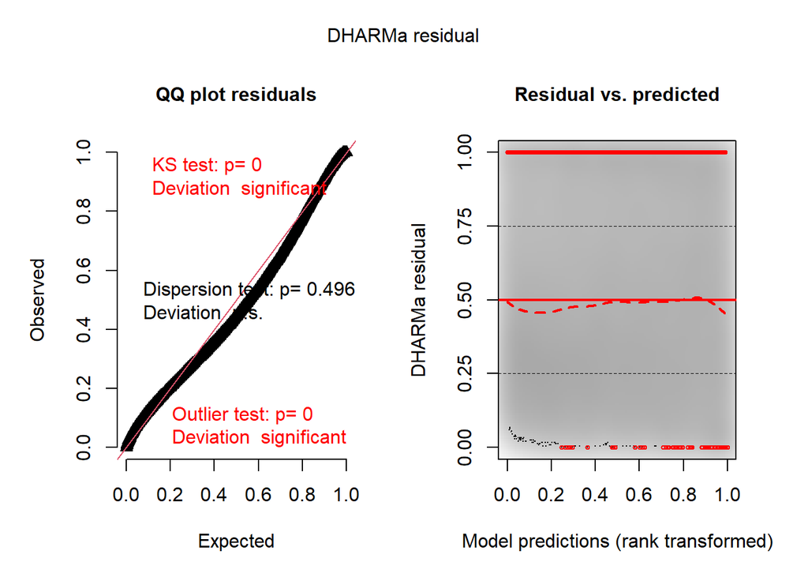

```
## Object of Class DHARMa with simulated residuals based on 250 simulations with refit = FALSE . See ?DHARMa::simulateResiduals for help.
##
## Scaled residual values: 0.296 0.044 0.08 0.036 0.104 0.192 0.624 0.22 0.608 0.692 0.736 0.548 0.656 0.984 0.724 0.748 0.584 0.5 0.508 0.716 ...
```

```r
# Model diagnostics
DHARMa::simulateResiduals(fittedModel = RH_gam1,
                          plot = TRUE)
```

```r
# Check for collinearity
car::vif(RH_gam1)
```

```
##                      GVIF Df GVIF^(1/(2*Df))
## Veg_Type    1.138375e+205  0             Inf
## Lat_scaled  1.138375e+205  0             Inf
## Long_scaled 1.138375e+205  0             Inf
## Year_scaled 1.138375e+205  0             Inf
## Day_scaled  1.138375e+205  0             Inf
## Station_ID  1.138375e+205  0             Inf
```

I then repeated the process with the wind speed HGAM. The summary showed that most of the vegetation types did not have a significant effect on wind speed (WS). The interaction of day and year by vegetation type is highly significant for all vegetation types. Additionally, this model shows some errors. For example the R squared value is low, meaning the model does a poor job explaining the variance. There are some variance issues in the plots as well. Finally, the VIF numbers are very large, which suggest multicollinearity issues. At this point, it was determined that additional models were needed to better explain this data.

```r
# Model summary
summary(WS_gam1)
```

```
##
## Family: gaussian
## Link function: log
##
## Formula:
## Wind_mph_max ~ te(Lat_scaled, Long_scaled) + te(Year_scaled,
##     Day_scaled, by = Veg_Type) + s(Station_ID, bs = "re") + Veg_Type
##
## Parametric coefficients:
##                        Estimate Std. Error t value Pr(>|t|)
## (Intercept)             2.61551    0.10529  24.842   <2e-16 ***
## Veg_TypeFlint Hills    -0.11740    0.13859  -0.847    0.397
## Veg_TypeN. Mixed Grass  0.06565    0.26704   0.246    0.806
## Veg_TypeN.ShortGrass    0.02612    0.26019   0.100    0.920
## Veg_TypeS.Mixed Grass   0.12935    0.13017   0.994    0.320
## Veg_TypeS.Short Grass   0.20910    0.16822   1.243    0.214
## Veg_TypeTall Grass     -0.10960    0.10131  -1.082    0.279
## ---
## Signif. codes:  0 '***' 0.001 '**' 0.01 '*' 0.05 '.' 0.1 ' ' 1
##
## Approximate significance of smooth terms:
##                                                      edf Ref.df       F p-value
## te(Lat_scaled,Long_scaled)                         13.90  13.98   0.869   0.602
## te(Year_scaled,Day_scaled):Veg_TypeEdwards Plateau 16.72  20.17  21.172  <2e-16
## te(Year_scaled,Day_scaled):Veg_TypeFlint Hills     19.29  22.17  12.809  <2e-16
## te(Year_scaled,Day_scaled):Veg_TypeN. Mixed Grass  20.02  22.62  18.722  <2e-16
## te(Year_scaled,Day_scaled):Veg_TypeN.ShortGrass    20.37  22.87  14.984  <2e-16
## te(Year_scaled,Day_scaled):Veg_TypeS.Mixed Grass   22.63  23.78  64.858  <2e-16
## te(Year_scaled,Day_scaled):Veg_TypeS.Short Grass   22.85  23.85  94.467  <2e-16
## te(Year_scaled,Day_scaled):Veg_TypeTall Grass      22.51  23.77 120.009  <2e-16
## s(Station_ID)                                      51.47  63.00  82.989  <2e-16
##
## te(Lat_scaled,Long_scaled)
## te(Year_scaled,Day_scaled):Veg_TypeEdwards Plateau ***
## te(Year_scaled,Day_scaled):Veg_TypeFlint Hills     ***
## te(Year_scaled,Day_scaled):Veg_TypeN. Mixed Grass  ***
## te(Year_scaled,Day_scaled):Veg_TypeN.ShortGrass    ***
## te(Year_scaled,Day_scaled):Veg_TypeS.Mixed Grass   ***
## te(Year_scaled,Day_scaled):Veg_TypeS.Short Grass   ***
## te(Year_scaled,Day_scaled):Veg_TypeTall Grass      ***
## s(Station_ID)                                      ***
## ---
## Signif. codes:  0 '***' 0.001 '**' 0.01 '*' 0.05 '.' 0.1 ' ' 1
##
## R-sq.(adj) =  0.215   Deviance explained = 21.6%
## fREML = 3.305e+05  Scale est. = 32.365    n = 104530
```

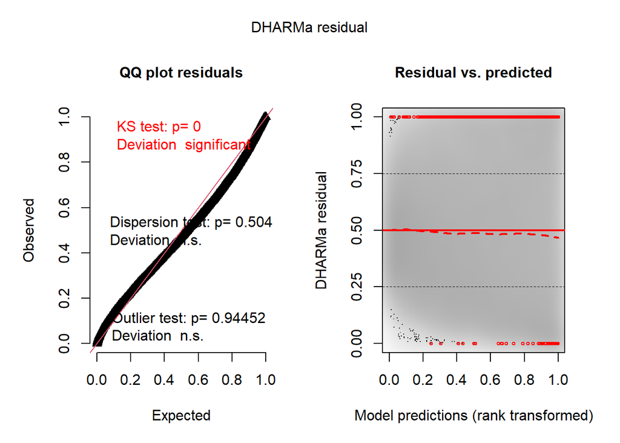

```
## Object of Class DHARMa with simulated residuals based on 250 simulations with refit = FALSE . See ?DHARMa::simulateResiduals for help.
##
## Scaled residual values: 0.544 0.432 0.204 0.188 0.248 0.736 0.576 0.772 0.224 0.856 0.616 0.976 0.8 0.816 0.228 0.016 0.068 0.164 0.796 0.564 ...
```

```r
# Model diagnostics
DHARMa::simulateResiduals(fittedModel = WS_gam1,
                          plot = TRUE)
```

```r
# Check for collinearity
car::vif(WS_gam1)
```

```
##                      GVIF Df GVIF^(1/(2*Df))
## Veg_Type    5.378019e+240  0             Inf
## Lat_scaled  5.378019e+240  0             Inf
## Long_scaled 5.378019e+240  0             Inf
## Year_scaled 5.378019e+240  0             Inf
## Day_scaled  5.378019e+240  0             Inf
## Station_ID  5.378019e+240  0             Inf
```

I then chose to run a few different models based on other options. The first of which, I used separate smooth terms for the latitude and longitude. The second one includes an interaction effect between station ID and year. This was chosen to account for the possibility of RH varying across each year and site due to localized climate factors. The third one uses a Gamma distribution instead of a normal one. Since this response is non-negative, the normal distribution might not be the best one for this data.

```r
RH_gam2 <- bam(RH_per_min ~ s(Lat_scaled, bs = "tp") + s(Long_scaled, bs = "tp")
               + te(Year_scaled, Day_scaled, by = Veg_Type)
               + s(Station_ID, bs = "re")
               + Veg_Type,
               family = gaussian("log"),
               data = weather_new)
RH_gam3 <- bam(RH_per_min ~ s(Lat_scaled, Long_scaled, bs = "tp")
               + te(Year_scaled, Day_scaled, by = Veg_Type)
               + s(Station_ID, by = Year_scaled, bs = "re")  # Station-year interaction
               + Veg_Type,
               family = gaussian("log"),
               data = weather_new)
RH_gam4 <- bam(RH_per_min ~ s(Lat_scaled, Long_scaled, bs = "tp")
               + te(Year_scaled, Day_scaled, by = Veg_Type)
               + s(Station_ID, bs = "re")
               + Veg_Type,
               family = Gamma(link = "log"),
               data = weather_new)
```

I then did the same thing with the Wind Speed response. For consistency’s sake I make the same changes to the global model.

```r
WS_gam2 <- bam(Wind_mph_max ~ s(Lat_scaled, bs = "tp") + s(Long_scaled, bs = "tp")
               + te(Year_scaled, Day_scaled, by = Veg_Type)
               + s(Station_ID, bs = "re")
               + Veg_Type,
               family = gaussian("log"),
               data = weather_new)
WS_gam3 <- bam(Wind_mph_max ~ s(Lat_scaled, Long_scaled, bs = "tp")
               + te(Year_scaled, Day_scaled, by = Veg_Type)
               + s(Station_ID, by = Year_scaled, bs = "re")  # Station-year interaction
               + Veg_Type,
               family = gaussian("log"),
               data = weather_new)
WS_gam4 <- bam(Wind_mph_max ~ s(Lat_scaled, Long_scaled, bs = "tp")
               + te(Year_scaled, Day_scaled, by = Veg_Type)
               + s(Station_ID, bs = "re")
               + Veg_Type,
               family = Gamma(link = "log"),
               data = weather_new)
```

**Model Selection** Next, I used model selection to pick the best of the HGAMS I had come up with. For RH, the best model was the gamma model. It had an AIC of 855658.9 and a weight of 1. This is very clearly the best model for RH I created.

```r
model.sel(list(global = RH_gam1,
               seperate_lat_long = RH_gam2,
               state_year = RH_gam3,
               gamma = RH_gam4))
```

```
## Model selection table
##                   (Int) s(Stt_ID,"re") te(Lat_scl,Lng_scl)
## gamma             3.820              +
## seperate_lat_long 3.824              +
## global            3.781              +                   +
## state_year        3.767
##                   te(Yer_scl,Day_scl,Veg_Typ) Veg_Typ s(Lat_scl,"tp")
## gamma                                       +       +
## seperate_lat_long                           +       +               +
## global                                      +       +
## state_year                                  +       +
##                   s(Lng_scl,"tp") s(Lat_scl,Lng_scl,"tp")
## gamma                                                   +
## seperate_lat_long               +
## global
## state_year                                              +
##                   s(Stt_ID,Yer_scl,"re") family  df    logLik     AICc   delta
## gamma                                    Gm(lg) 233 -427595.2 855658.9    0.00
## seperate_lat_long                        gs(lg) 234 -427688.4 855847.2  188.25
## global                                   gs(lg) 234 -427689.3 855849.1  190.15
## state_year                             + gs(lg) 257 -428591.4 857699.7 2040.74
##                   weight
## gamma                  1
## seperate_lat_long      0
## global                 0
## state_year             0
## Abbreviations:
##  family: Gm(lg) = 'Gamma(log)', gs(lg) = 'gaussian(log)'
## Models ranked by AICc(x)
```

```r
model.sel(list(global = WS_gam1,
               seperate_lat_long = WS_gam2,
               state_year = WS_gam3,
               gamma = WS_gam4))
```

```
## Model selection table
##                   (Int) s(Stt_ID,"re") te(Lat_scl,Lng_scl)
## gamma             2.567              +
## global            2.616              +                   +
## seperate_lat_long 2.578              +
## state_year        2.508
##                   te(Yer_scl,Day_scl,Veg_Typ) Veg_Typ s(Lat_scl,"tp")
## gamma                                       +       +
## global                                      +       +
## seperate_lat_long                           +       +               +
## state_year                                  +       +
##                   s(Lng_scl,"tp") s(Lat_scl,Lng_scl,"tp")
## gamma                                                   +
## global
## seperate_lat_long               +
## state_year                                              +
##                   s(Stt_ID,Yer_scl,"re") family na.action  df    logLik
## gamma                                    Gm(lg)           224 -315505.1
## global                                   gs(lg)   na.omit 222 -329943.2
## seperate_lat_long                        gs(lg)           222 -329946.0
## state_year                             + gs(lg)           241 -331953.4
##                       AICc    delta weight
## gamma             631459.2     0.00      1
## global            660332.8 28873.60      0
## seperate_lat_long 660339.0 28879.73      0
## state_year        664390.9 32931.71      0
## Abbreviations:
##  family: Gm(lg) = 'Gamma(log)', gs(lg) = 'gaussian(log)'
## Models ranked by AICc(x)
```

## Results

I have the top fit of my models. The summary of both is below. The fixed effects of vegetation were included as categorical predictors, but none of the different types showed a difference in relative humidity. As such, vegetation has little effect on RH across sites. The smooth term for latitude and longitude was not statistically significant (p = 0.167), meaning that location had little effect on RH once other factors were introduced. All of the temporal smooth terms by vegetation type were highly significant (p < 0.001). The seasonal variation of RH differs dramatically across variation types. Finally, the random effect of station ID was also significant. This indicates that RH is likely impacted by certain station-specific factors.

```r
summary(RH_gam4)
```

```
##
## Family: Gamma
## Link function: log
##
## Formula:
## RH_per_min ~ s(Lat_scaled, Long_scaled, bs = "tp") + te(Year_scaled,
##     Day_scaled, by = Veg_Type) + s(Station_ID, bs = "re") + Veg_Type
##
## Parametric coefficients:
##                         Estimate Std. Error t value Pr(>|t|)
## (Intercept)             3.820070   0.081023  47.148   <2e-16 ***
## Veg_TypeFlint Hills    -0.038824   0.111867  -0.347    0.729
## Veg_TypeN. Mixed Grass  0.057156   0.197207   0.290    0.772
## Veg_TypeN.ShortGrass    0.107059   0.211962   0.505    0.613
## Veg_TypeS.Mixed Grass  -0.003805   0.100296  -0.038    0.970
## Veg_TypeS.Short Grass  -0.147499   0.135556  -1.088    0.277
## Veg_TypeTall Grass     -0.048574   0.080874  -0.601    0.548
## ---
## Signif. codes:  0 '***' 0.001 '**' 0.01 '*' 0.05 '.' 0.1 ' ' 1
##
## Approximate significance of smooth terms:
##                                                      edf Ref.df       F p-value
## s(Lat_scaled,Long_scaled)                          15.22  15.33   1.331   0.167
## te(Year_scaled,Day_scaled):Veg_TypeEdwards Plateau 22.88  23.87  41.911  <2e-16
## te(Year_scaled,Day_scaled):Veg_TypeFlint Hills     22.83  23.85  31.946  <2e-16
## te(Year_scaled,Day_scaled):Veg_TypeN. Mixed Grass  21.19  23.23  25.000  <2e-16
## te(Year_scaled,Day_scaled):Veg_TypeN.ShortGrass    21.19  23.20  22.426  <2e-16
## te(Year_scaled,Day_scaled):Veg_TypeS.Mixed Grass   23.31  23.95 115.989  <2e-16
## te(Year_scaled,Day_scaled):Veg_TypeS.Short Grass   23.53  23.97 271.046  <2e-16
## te(Year_scaled,Day_scaled):Veg_TypeTall Grass      23.67  23.99 177.222  <2e-16
## s(Station_ID)                                      50.18  64.00  50.748  <2e-16
##
## s(Lat_scaled,Long_scaled)
## te(Year_scaled,Day_scaled):Veg_TypeEdwards Plateau ***
## te(Year_scaled,Day_scaled):Veg_TypeFlint Hills     ***
## te(Year_scaled,Day_scaled):Veg_TypeN. Mixed Grass  ***
## te(Year_scaled,Day_scaled):Veg_TypeN.ShortGrass    ***
## te(Year_scaled,Day_scaled):Veg_TypeS.Mixed Grass   ***
## te(Year_scaled,Day_scaled):Veg_TypeS.Short Grass   ***
## te(Year_scaled,Day_scaled):Veg_TypeTall Grass      ***
## s(Station_ID)                                      ***
## ---
## Signif. codes:  0 '***' 0.001 '**' 0.01 '*' 0.05 '.' 0.1 ' ' 1
##
## R-sq.(adj) =  0.267   Deviance explained = 26.5%
## fREML =  38309  Scale est. = 0.12058   n = 104552
```

Like RH, for WS the effects of vegetation were included as categorical predictors, but none of the different types showed a difference in relative humidity. As such, vegetation has little effect on WS across sites. The smooth term for latitude and longitude was not statistically significant (p = 0.416), meaning that location had little effect on WS once other factors were introduced. All of the temporal smooth terms by vegetation type were highly significant (p < 0.001). The seasonal variation of WS differs dramatically across variation types. Finally, the random effect of station ID was also significant. This indicates that WS is likely impacted by certain station-specific factors. The models show that these variables explain both RH and WS in very similar ways.

```r
summary(WS_gam4)
```

```
##
## Family: Gamma
## Link function: log
##
## Formula:
## Wind_mph_max ~ s(Lat_scaled, Long_scaled, bs = "tp") + te(Year_scaled,
##     Day_scaled, by = Veg_Type) + s(Station_ID, bs = "re") + Veg_Type
##
## Parametric coefficients:
##                        Estimate Std. Error t value Pr(>|t|)
## (Intercept)             2.56723    0.09842  26.085   <2e-16 ***
## Veg_TypeFlint Hills    -0.03025    0.13630  -0.222    0.824
## Veg_TypeN. Mixed Grass  0.10985    0.25495   0.431    0.667
## Veg_TypeN.ShortGrass    0.09124    0.27139   0.336    0.737
## Veg_TypeS.Mixed Grass   0.19257    0.12279   1.568    0.117
## Veg_TypeS.Short Grass   0.25145    0.16842   1.493    0.135
## Veg_TypeTall Grass     -0.06048    0.09628  -0.628    0.530
## ---
## Signif. codes:  0 '***' 0.001 '**' 0.01 '*' 0.05 '.' 0.1 ' ' 1
##
## Approximate significance of smooth terms:
##                                                      edf Ref.df      F p-value
## s(Lat_scaled,Long_scaled)                          17.01  17.09   1.03   0.416
## te(Year_scaled,Day_scaled):Veg_TypeEdwards Plateau 18.78  21.84  27.85  <2e-16
## te(Year_scaled,Day_scaled):Veg_TypeFlint Hills     20.08  22.64  15.51  <2e-16
## te(Year_scaled,Day_scaled):Veg_TypeN. Mixed Grass  19.14  22.00  17.47  <2e-16
## te(Year_scaled,Day_scaled):Veg_TypeN.ShortGrass    19.68  22.43  13.55  <2e-16
## te(Year_scaled,Day_scaled):Veg_TypeS.Mixed Grass   22.46  23.71  56.82  <2e-16
## te(Year_scaled,Day_scaled):Veg_TypeS.Short Grass   22.63  23.79  71.96  <2e-16
## te(Year_scaled,Day_scaled):Veg_TypeTall Grass      22.66  23.81 136.37  <2e-16
## s(Station_ID)                                      48.51  64.00 109.11  <2e-16
##
## s(Lat_scaled,Long_scaled)
## te(Year_scaled,Day_scaled):Veg_TypeEdwards Plateau ***
## te(Year_scaled,Day_scaled):Veg_TypeFlint Hills     ***
## te(Year_scaled,Day_scaled):Veg_TypeN. Mixed Grass  ***
## te(Year_scaled,Day_scaled):Veg_TypeN.ShortGrass    ***
## te(Year_scaled,Day_scaled):Veg_TypeS.Mixed Grass   ***
## te(Year_scaled,Day_scaled):Veg_TypeS.Short Grass   ***
## te(Year_scaled,Day_scaled):Veg_TypeTall Grass      ***
## s(Station_ID)                                      ***
## ---
## Signif. codes:  0 '***' 0.001 '**' 0.01 '*' 0.05 '.' 0.1 ' ' 1
##
## R-sq.(adj) =  0.213   Deviance explained = 24.5%
## fREML =  46065  Scale est. = 0.14012   n = 104530
```

Now that I have a top fit, I can start the actual analysis. I then made prediction plots based off the RH of each year. In general, across most years, RH increased during the sampling time, with a peak in early summer. There did also seem to be higher humidity in summer over the later times of the later years.

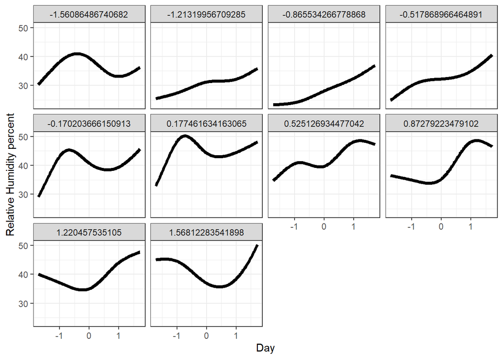

```r
nd <- expand.grid(Station_ID = weather_new$Station_ID[1],
                 Veg_Type = "S.Short Grass",
                 Lat_scaled = 0.128,
                 Long_scaled = -1.13,
                 Day_scaled = (121:273 - mean(weather_new$Day)) / sd(weather_new$Day),
                 Year_scaled = (2010:2019 - mean(weather_new$Year)) / sd(weather_new$Year))

fit_values <- predict(RH_gam4, newdata = nd, type = "response", se.fit = FALSE)
nd$fit <- fit_values

pred <- as.data.frame(fit = predict(RH_gam4, nd, type = "response", se.fit = FALSE),nd )


ggplot(pred, aes(x = Day_scaled, y = fit, group = Year_scaled)) +
  geom_line(linewidth = 1.5) +
  facet_wrap(~as.factor(Year_scaled)) + theme_bw() +
  ylab("Relative Humidity percent") +
  xlab("Day")
```

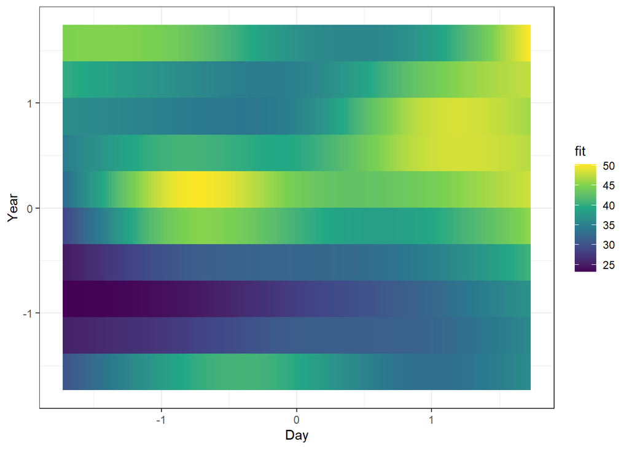

```r
ggplot(pred, aes(x = Day_scaled, y = Year_scaled, fill = fit)) +
  geom_tile() +
  scale_fill_viridis_c() +
  theme_bw() +
  ylab("Year") +
  xlab("Day")
```

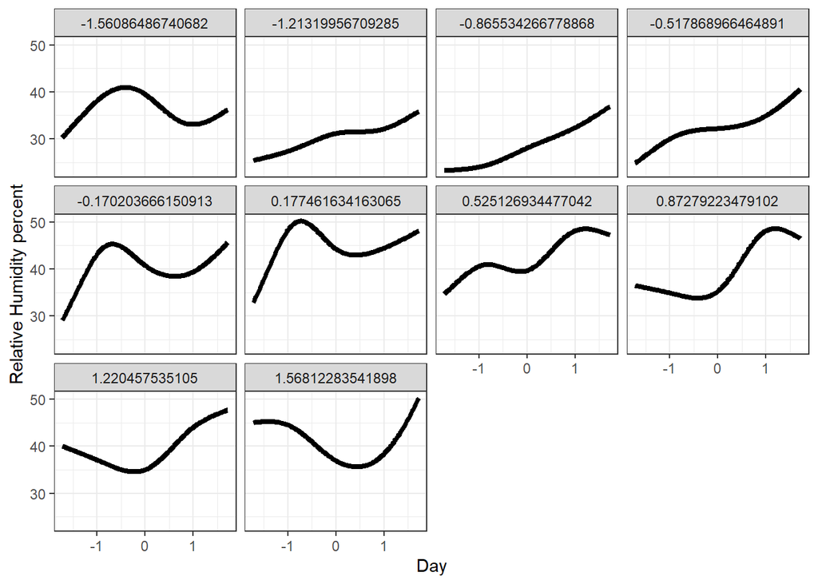

```r
ndw <- expand.grid(Station_ID = weather_new$Station_ID[1],
                 Veg_Type = "S.Short Grass",
                 Lat_scaled = 0.128,
                 Long_scaled = -1.13,
                 Day_scaled = (121:273 - mean(weather_new$Day)) / sd(weather_new$Day),
                 Year_scaled = (2010:2019 - mean(weather_new$Year)) / sd(weather_new$Year))

fit_valuesw <- predict(WS_gam4, newdata = ndw, type = "response", se.fit = FALSE)
ndw$fit <- fit_values

predw <- as.data.frame(fit = predict(WS_gam4, nd, type = "response", se.fit = FALSE),nd )


ggplot(predw, aes(x = Day_scaled, y = fit, group = Year_scaled)) +
  geom_line(linewidth = 1.5) +
  facet_wrap(~as.factor(Year_scaled)) + theme_bw() +
  ylab("Relative Humidity percent") +
  xlab("Day")
```

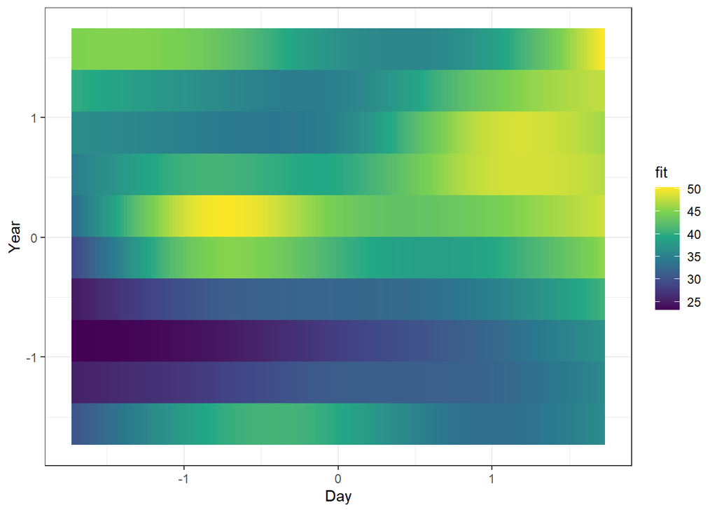

```r
ggplot(predw, aes(x = Day_scaled, y = Year_scaled, fill = fit)) +
  geom_tile() +
  scale_fill_viridis_c() +
  theme_bw() +
  ylab("Year") +
  xlab("Day")
```

## Conclusion

The HGAMs that were produced were made to observe the trend of relative humidity (RH) and wind speed (WS) over time and space. These results provide key insights into the underlying relationships in the data.

Overall, the results suggest that while vegetation type does not have a strong linear effect on RH or WS, there are significant seasonal patterns that vary by vegetation type. Both models showed insignificant effects of latitude and longitude. The random effects of the station accounted for substantial variability in RH and WS, underscoring the importance of station-level differences. The significant temporal smooth terms highlight the importance of accounting for the changing nature of RH and WS over the course of the year, with variation across different vegetation types. There also seems to be a general increase of humidity not only within a year, but across them as well. This may indicate possible effects due to global warming.

Overall, both models explained the data. However, the R squared values for both were small. This isn’t out of the norm for an enviromental study, as the environment tends to have complicated effects, but it does mean that both models leave a lot of variation unexplained. The importance of station ID hints that there may be other station conditions that are not reported that may cause some of these variations. In future research, conditions of the stations (weather, topography, etc) should be recorded. Finally, the models showed seasonal effects on both RH and WS. Extending the study to encompass more seasons may help as well.